# Cyclistic R Markdown

# Conduct Descriptive Analysis

Note: Descriptive analysis on ride_length (all figures in seconds) and comparing member vs casual user and their mean max and min ride length. We need to set days of the week in order to make it easier to read.

```r
aggregate(all_trips_v2$ride_length ~ all_trips_v2$member_casual, FUN = mean)
```

```
##   all_trips_v2$member_casual all_trips_v2$ride_length
## 1                     casual                 2749.376
## 2                     member                  973.974
```

```r
aggregate(all_trips_v2$ride_length ~ all_trips_v2$member_casual, FUN = median)
```

```
##   all_trips_v2$member_casual all_trips_v2$ride_length
## 1                     casual                     1293
## 2                     member                      695
```

```r
aggregate(all_trips_v2$ride_length ~ all_trips_v2$member_casual, FUN = max)
```

```
##   all_trips_v2$member_casual all_trips_v2$ride_length
## 1                     casual                  3341033
## 2                     member                  3523202
```

```r
aggregate(all_trips_v2$ride_length ~ all_trips_v2$member_casual, FUN = min)
```

```
##   all_trips_v2$member_casual all_trips_v2$ride_length
## 1                     casual                        0
## 2                     member                        0
```

```r
all_trips_v2$day_of_week <- ordered(all_trips_v2$day_of_week, levels=c("Sunday", "Monday", "Tuesday", "Wednesday", "Thursday", "Friday", "Saturday"))

aggregate(all_trips_v2$ride_length ~ all_trips_v2$member_casual + all_trips_v2$day_of_week, FUN = mean)
```

```
##    all_trips_v2$member_casual all_trips_v2$day_of_week all_trips_v2$ride_length
## 1                      casual                   Sunday                3094.3241
## 2                      member                   Sunday                1103.4337
## 3                      casual                   Monday                2756.5101
## 4                      member                   Monday                 927.1667
## 5                      casual                  Tuesday                2480.4720
## 6                      member                  Tuesday                 914.0390
## 7                      casual                Wednesday                2471.3060
## 8                      member                Wednesday                 923.9081
## 9                      casual                 Thursday                2632.8978
## 10                     member                 Thursday                 918.3857
## 11                     casual                   Friday                2617.0818
## 12                     member                   Friday                 955.0886
## 13                     casual                 Saturday                2860.8466
## 14                     member                 Saturday                1076.2081
```

# Plot Number of Rides per user type (by day of week)

Note: n() is to get number of rides count

```r
library(scales)
```

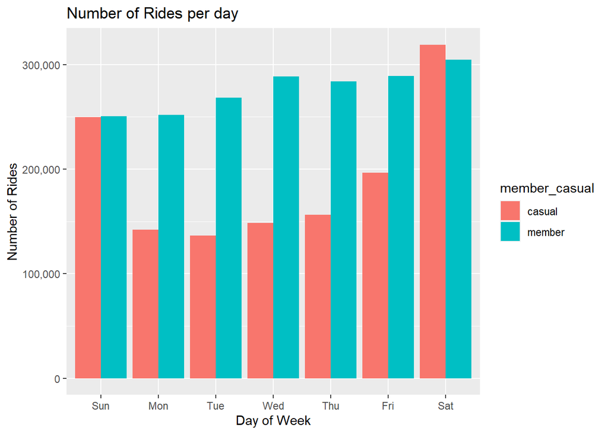

```r
all_trips_v2 %>%
  mutate(weekday = wday(started_at, label = TRUE)) %>%
  group_by(member_casual, weekday) %>%
  drop_na() %>%
  summarise(number_of_rides = n()
            ,average_duration = mean(ride_length)) %>%
  arrange(member_casual, weekday)  %>%
  ggplot(aes(x = weekday, y = number_of_rides, fill = member_casual)) +
  geom_col(position = "dodge") +
  labs(title="Number of Rides per day",x = "Day of Week", y = "Number of Rides") +
  scale_y_continuous(labels = comma)
```

# Plot Average Ride length per user type (by day of week)

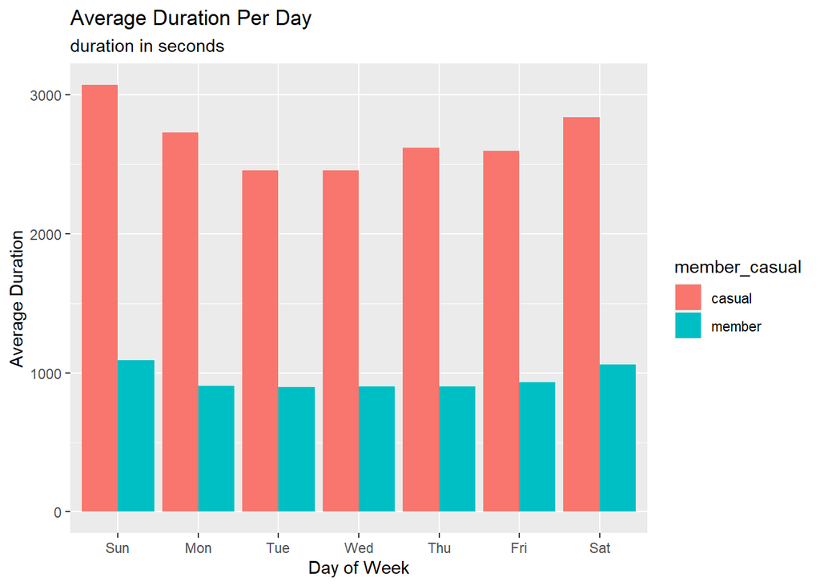

```r
  all_trips_v2 %>%
    mutate(weekday = wday(started_at, label = TRUE)) %>%
    group_by(member_casual, weekday) %>%
    drop_na() %>%
    summarise(number_of_rides = n()
              ,average_duration = mean(ride_length)) %>%
    arrange(member_casual, weekday)  %>%
    ggplot(aes(x = weekday, y = average_duration, fill = member_casual)) +
    geom_col(position = "dodge") +
    labs(title="Average Duration Per Day",subtitle="duration in seconds",x = "Day of Week", y = "Average Duration")
```

# Plot Number of Rides per user type (by month)

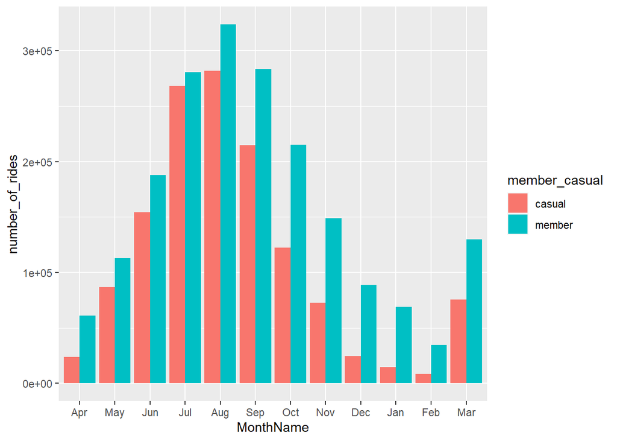

```r
all_trips_v2 %>%
  mutate(MonthName = month.abb[Month]) %>%
  group_by(member_casual,MonthName) %>%
  drop_na() %>%
  summarise(number_of_rides = n(),
            average_duration = mean(ride_length)) %>%
  arrange(member_casual) %>%
  ggplot(aes(x=MonthName,y=number_of_rides,fill=member_casual)) +
  geom_col(position="dodge") +
  scale_x_discrete(limits = c("Apr", "May", "Jun", "Jul", "Aug",
                             "Sep", "Oct", "Nov", "Dec", "Jan",
                             "Feb", "Mar"))
```

# Plot Average Ride Length per user type

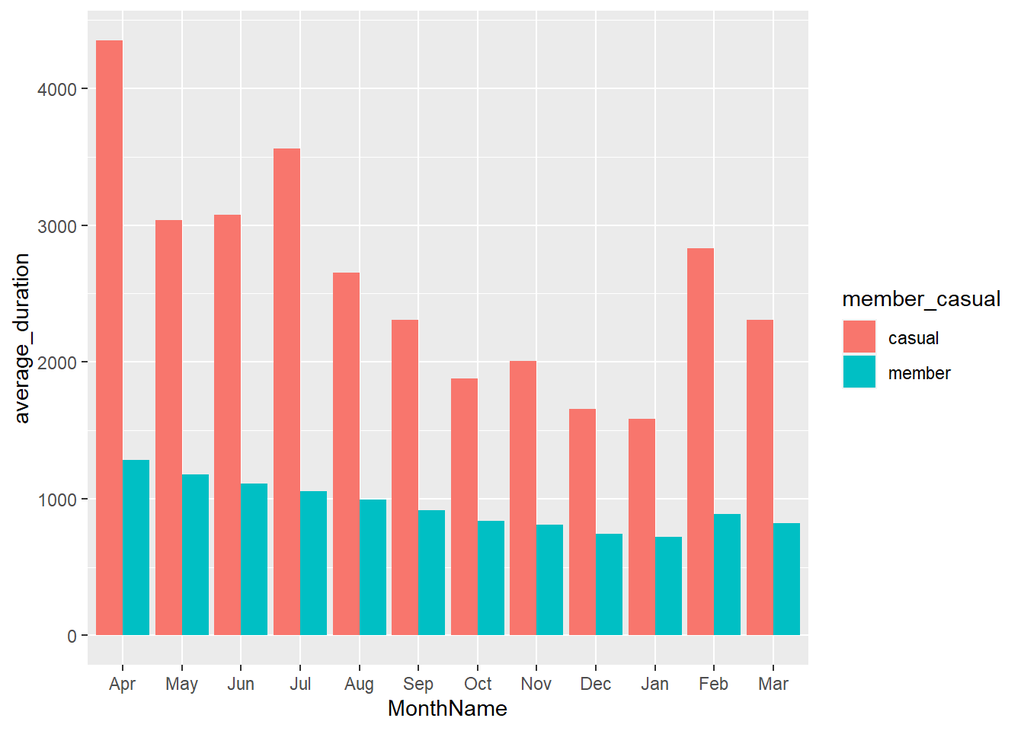

```r
all_trips_v2 %>%
  mutate(MonthName = month.abb[Month]) %>%
  group_by(member_casual,MonthName) %>%
  drop_na() %>%
  summarise(number_of_rides = n(),
            average_duration = mean(ride_length)) %>%
  arrange(member_casual) %>%
  ggplot(aes(x=MonthName,y=average_duration,fill=member_casual)) +
  geom_col(position="dodge") +
  scale_x_discrete(limits = c("Apr", "May", "Jun", "Jul", "Aug",
                              "Sep", "Oct", "Nov", "Dec", "Jan",
                              "Feb", "Mar"))
```

# Export summary file for further analysis (by day of week & by month)

```r
trips_csv <- all_trips_v2 %>%
  mutate(weekday = wday(started_at, label = TRUE)) %>%
  group_by(member_casual, weekday) %>%
  drop_na() %>%
  summarise(number_of_rides = n()
            ,average_duration = mean(ride_length)) %>%
  arrange(member_casual, weekday)
write.csv(trips_csv, file = 'C:/Users/vapor/OneDrive/Documents/Cyclistic/summary.csv')

testing_csv <- all_trips_v2 %>%
  mutate(MonthName = month.abb[Month]) %>%
  group_by(member_casual,MonthName) %>%
  drop_na() %>%
  summarise(number_of_rides = n(),
            average_duration = mean(ride_length)) %>%
  arrange(member_casual)
write.csv(testing_csv, file = 'C:/Users/vapor/OneDrive/Documents/Cyclistic/banana.csv')
```